# IODS course project

### Scaling the Boston dataset

Scaling the Boston dataset changed original variables so, that the mean is 0. The histograms show that scaling did not alter the distributions.

```
##       crim                 zn               indus
##  Min.   :-0.419367   Min.   :-0.48724   Min.   :-1.5563
##  1st Qu.:-0.410563   1st Qu.:-0.48724   1st Qu.:-0.8668
##  Median :-0.390280   Median :-0.48724   Median :-0.2109
##  Mean   : 0.000000   Mean   : 0.00000   Mean   : 0.0000
##  3rd Qu.: 0.007389   3rd Qu.: 0.04872   3rd Qu.: 1.0150
##  Max.   : 9.924110   Max.   : 3.80047   Max.   : 2.4202
##       chas              nox                rm               age
##  Min.   :-0.2723   Min.   :-1.4644   Min.   :-3.8764   Min.   :-2.3331
##  1st Qu.:-0.2723   1st Qu.:-0.9121   1st Qu.:-0.5681   1st Qu.:-0.8366
##  Median :-0.2723   Median :-0.1441   Median :-0.1084   Median : 0.3171
##  Mean   : 0.0000   Mean   : 0.0000   Mean   : 0.0000   Mean   : 0.0000
##  3rd Qu.:-0.2723   3rd Qu.: 0.5981   3rd Qu.: 0.4823   3rd Qu.: 0.9059
##  Max.   : 3.6648   Max.   : 2.7296   Max.   : 3.5515   Max.   : 1.1164
##       dis               rad               tax             ptratio
##  Min.   :-1.2658   Min.   :-0.9819   Min.   :-1.3127   Min.   :-2.7047
##  1st Qu.:-0.8049   1st Qu.:-0.6373   1st Qu.:-0.7668   1st Qu.:-0.4876
##  Median :-0.2790   Median :-0.5225   Median :-0.4642   Median : 0.2746
##  Mean   : 0.0000   Mean   : 0.0000   Mean   : 0.0000   Mean   : 0.0000
##  3rd Qu.: 0.6617   3rd Qu.: 1.6596   3rd Qu.: 1.5294   3rd Qu.: 0.8058
##  Max.   : 3.9566   Max.   : 1.6596   Max.   : 1.7964   Max.   : 1.6372
##      black             lstat              medv
##  Min.   :-3.9033   Min.   :-1.5296   Min.   :-1.9063
##  1st Qu.: 0.2049   1st Qu.:-0.7986   1st Qu.:-0.5989
##  Median : 0.3808   Median :-0.1811   Median :-0.1449
##  Mean   : 0.0000   Mean   : 0.0000   Mean   : 0.0000
##  3rd Qu.: 0.4332   3rd Qu.: 0.6024   3rd Qu.: 0.2683
##  Max.   : 0.4406   Max.   : 3.5453   Max.   : 2.9865
```

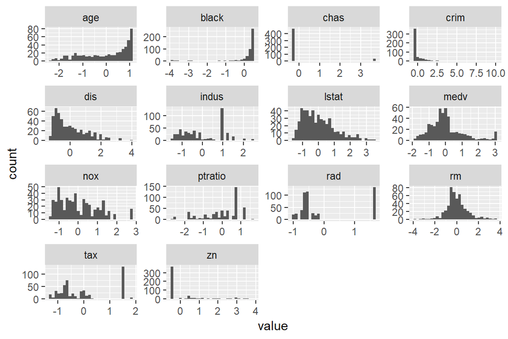

### Creating the categorical crime variable and dividing the dataset

Frequencies of the new categorical crime-variable:

```r
# creating a quantile vector of crim
bins <- quantile(boston_scaled$crim)

# create a categorical variable 'crime'
crime <- cut(boston_scaled$crim, breaks = bins, include.lowest = TRUE, labels = c("low", "med_low", "med_high", "high"))

# removing original crim from the dataset
boston_scaled <- dplyr::select(boston_scaled, -crim)

# adding the new categorical value to scaled data
boston_scaled <- data.frame(boston_scaled, crime)

table(boston_scaled$crime)
```

```
##
##      low  med_low med_high     high
##      127      126      126      127
```

Next, the original data is divided into two datasets: “train” and “test”. The “train” dataset includes 80 % of the original observations and we used it to create a model to predict crime class. Then we test the model to predict the crime class in the “test” dataset.

```r
#Dividing the dataset to two: test & train
# number of rows in the Boston dataset
n <- nrow(Boston)

# choose randomly 80% of the rows
ind <- sample(n,  size = n * 0.8)

# create train set
train <- boston_scaled[ind,]

# create test set
test <- boston_scaled[-ind,]
```

### Linear discriminant analysis

```
## Call:
## lda(crime ~ ., data = train)
##
## Prior probabilities of groups:
##       low   med_low  med_high      high
## 0.2400990 0.2351485 0.2772277 0.2475248
##
## Group means:
##                  zn      indus        chas        nox          rm
## low       0.9453866 -0.9677563 -0.10997442 -0.8800981  0.43675389
## med_low  -0.1085674 -0.2880226 -0.02367011 -0.5613025 -0.12433614
## med_high -0.3861727  0.2091479  0.18465578  0.4223322  0.04669974
## high     -0.4872402  1.0171519 -0.15421606  1.0798883 -0.41603651
##                 age        dis        rad        tax    ptratio
## low      -0.8531100  0.9523318 -0.6823226 -0.7252221 -0.4456518
## med_low  -0.3251943  0.3190550 -0.5623785 -0.4802646 -0.0475310
## med_high  0.4039782 -0.3763138 -0.4219935 -0.3135469 -0.3366126
## high      0.8110132 -0.8374556  1.6377820  1.5138081  0.7803736
##                black       lstat         medv
## low       0.37720293 -0.74924195  0.512955936
## med_low   0.30856835 -0.10287577 -0.005169363
## med_high  0.05374837  0.02117647  0.138170134
## high     -0.88081112  0.92020447 -0.711507259
##
## Coefficients of linear discriminants:
##                  LD1          LD2         LD3
## zn       0.090791927  0.677317535 -0.88057840
## indus    0.033269856 -0.393351282  0.34017415
## chas    -0.110849049 -0.065282831  0.08579278
## nox      0.349612321 -0.662177419 -1.38350112
## rm      -0.072034039 -0.057583758 -0.06954278
## age      0.320540317 -0.277402930 -0.25315268
## dis     -0.005068241 -0.176428882 -0.02015610
## rad      3.191938700  0.885052052 -0.16146469
## tax      0.001914351  0.058200371  0.57837238
## ptratio  0.119122453  0.006127878 -0.23388366
## black   -0.112574342  0.012552768  0.12684236
## lstat    0.194496451 -0.131098915  0.42056942
## medv     0.165708758 -0.349310749 -0.24619692
##
## Proportion of trace:
##    LD1    LD2    LD3
## 0.9460 0.0415 0.0125
```

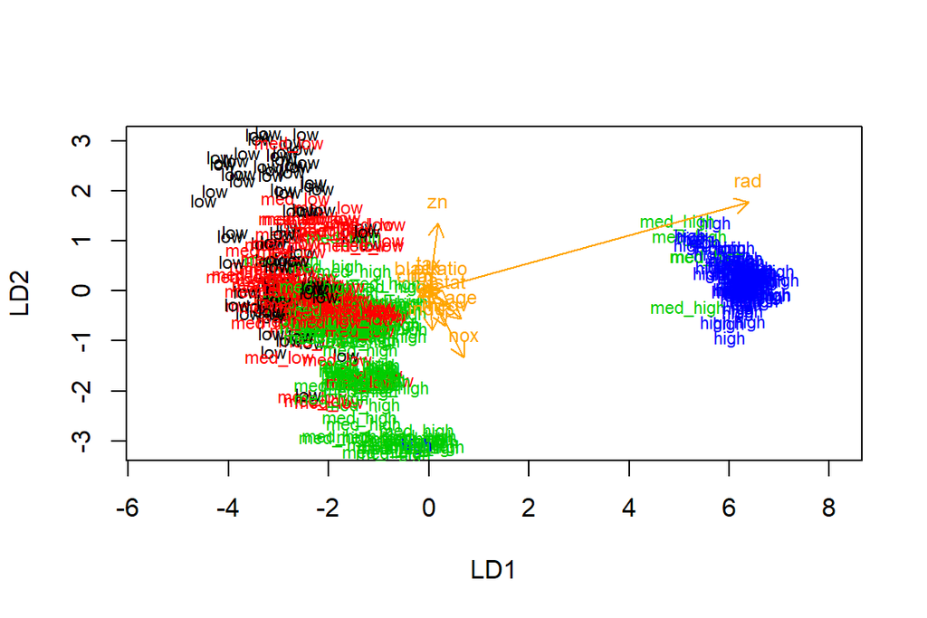

### Predicting the classes with the LDA model on the test data.

Cross-tabulation of the correct vs. predicted crime classes in the test data:

```r
# save the correct classes from test data
correct_classes <- test$crime

# remove the crime variable from test data
test <- dplyr::select(test, -crime)

# predict classes with test data
lda.pred <- predict(lda.fit, newdata = test)

# cross tabulate the results
table(correct = correct_classes, predicted = lda.pred$class)
```

```
##           predicted
## correct    low med_low med_high high
##   low       18       9        3    0
##   med_low    7      14       10    0
##   med_high   0       4        9    1
##   high       0       0        0   27
```

### K-means clustering

##### **Distances**

```
##       crim                 zn               indus
##  Min.   :-0.419367   Min.   :-0.48724   Min.   :-1.5563
##  1st Qu.:-0.410563   1st Qu.:-0.48724   1st Qu.:-0.8668
##  Median :-0.390280   Median :-0.48724   Median :-0.2109
##  Mean   : 0.000000   Mean   : 0.00000   Mean   : 0.0000
##  3rd Qu.: 0.007389   3rd Qu.: 0.04872   3rd Qu.: 1.0150
##  Max.   : 9.924110   Max.   : 3.80047   Max.   : 2.4202
##       chas              nox                rm               age
##  Min.   :-0.2723   Min.   :-1.4644   Min.   :-3.8764   Min.   :-2.3331
##  1st Qu.:-0.2723   1st Qu.:-0.9121   1st Qu.:-0.5681   1st Qu.:-0.8366
##  Median :-0.2723   Median :-0.1441   Median :-0.1084   Median : 0.3171
##  Mean   : 0.0000   Mean   : 0.0000   Mean   : 0.0000   Mean   : 0.0000
##  3rd Qu.:-0.2723   3rd Qu.: 0.5981   3rd Qu.: 0.4823   3rd Qu.: 0.9059
##  Max.   : 3.6648   Max.   : 2.7296   Max.   : 3.5515   Max.   : 1.1164
##       dis               rad               tax             ptratio
##  Min.   :-1.2658   Min.   :-0.9819   Min.   :-1.3127   Min.   :-2.7047
##  1st Qu.:-0.8049   1st Qu.:-0.6373   1st Qu.:-0.7668   1st Qu.:-0.4876
##  Median :-0.2790   Median :-0.5225   Median :-0.4642   Median : 0.2746
##  Mean   : 0.0000   Mean   : 0.0000   Mean   : 0.0000   Mean   : 0.0000
##  3rd Qu.: 0.6617   3rd Qu.: 1.6596   3rd Qu.: 1.5294   3rd Qu.: 0.8058
##  Max.   : 3.9566   Max.   : 1.6596   Max.   : 1.7964   Max.   : 1.6372
##      black             lstat              medv
##  Min.   :-3.9033   Min.   :-1.5296   Min.   :-1.9063
##  1st Qu.: 0.2049   1st Qu.:-0.7986   1st Qu.:-0.5989
##  Median : 0.3808   Median :-0.1811   Median :-0.1449
##  Mean   : 0.0000   Mean   : 0.0000   Mean   : 0.0000
##  3rd Qu.: 0.4332   3rd Qu.: 0.6024   3rd Qu.: 0.2683
##  Max.   : 0.4406   Max.   : 3.5453   Max.   : 2.9865
```

```
##    Min. 1st Qu.  Median    Mean 3rd Qu.    Max.
##  0.1343  3.4625  4.8241  4.9111  6.1863 14.3970
```

##### **Determining the number of clusters**

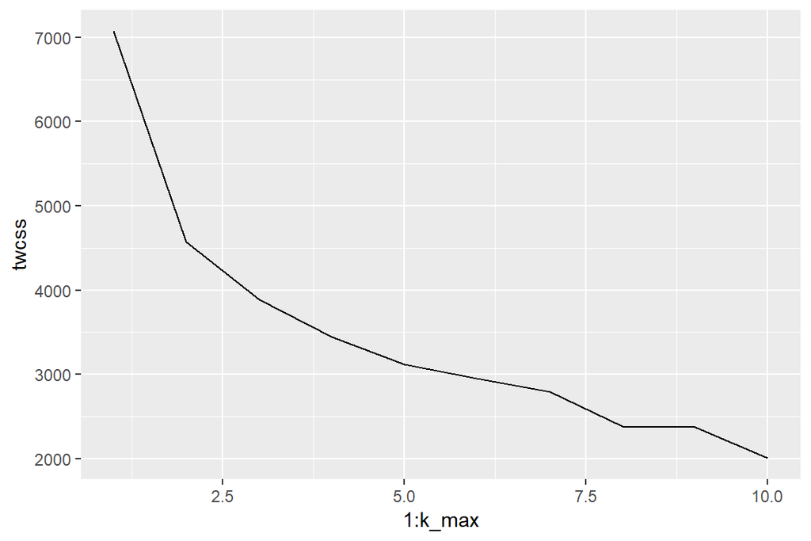

The optimal number of clusters seems to be 2, because the line flattens after that.

##### **Plotting clusters**

Below the plotted clusters are presented. To be honest, I can’t interpret the plots. I hope that I learn during peer review exercise :)

[figure not shown]

# Rstudio Exercise 5

## 1. Graphical overview and summaries of the variables

There are 8 numeric/integer variables in the ‘human’ data. Summaries of these variables are shown below:

```r
human <- read.csv("~/GitHub/IODS-project/data/human.csv", row.names=1)

summary(human)
```

```
##     Edu2.FM          Labo.FM          Life.Exp        Edu.Exp
##  Min.   :0.1717   Min.   :0.1857   Min.   :49.00   Min.   : 5.40
##  1st Qu.:0.7264   1st Qu.:0.5984   1st Qu.:66.30   1st Qu.:11.25
##  Median :0.9375   Median :0.7535   Median :74.20   Median :13.50
##  Mean   :0.8529   Mean   :0.7074   Mean   :71.65   Mean   :13.18
##  3rd Qu.:0.9968   3rd Qu.:0.8535   3rd Qu.:77.25   3rd Qu.:15.20
##  Max.   :1.4967   Max.   :1.0380   Max.   :83.50   Max.   :20.20
##       GNI            Mat.Mor         Ado.Birth         Parli.F
##  Min.   :   581   Min.   :   1.0   Min.   :  0.60   Min.   : 0.00
##  1st Qu.:  4198   1st Qu.:  11.5   1st Qu.: 12.65   1st Qu.:12.40
##  Median : 12040   Median :  49.0   Median : 33.60   Median :19.30
##  Mean   : 17628   Mean   : 149.1   Mean   : 47.16   Mean   :20.91
##  3rd Qu.: 24512   3rd Qu.: 190.0   3rd Qu.: 71.95   3rd Qu.:27.95
##  Max.   :123124   Max.   :1100.0   Max.   :204.80   Max.   :57.50
```

First, I looked the distributions of the variables using histograms. Expected years of schooling (*Edu.Exp*) was close to normal distribution, but other variables were more or less skewed.

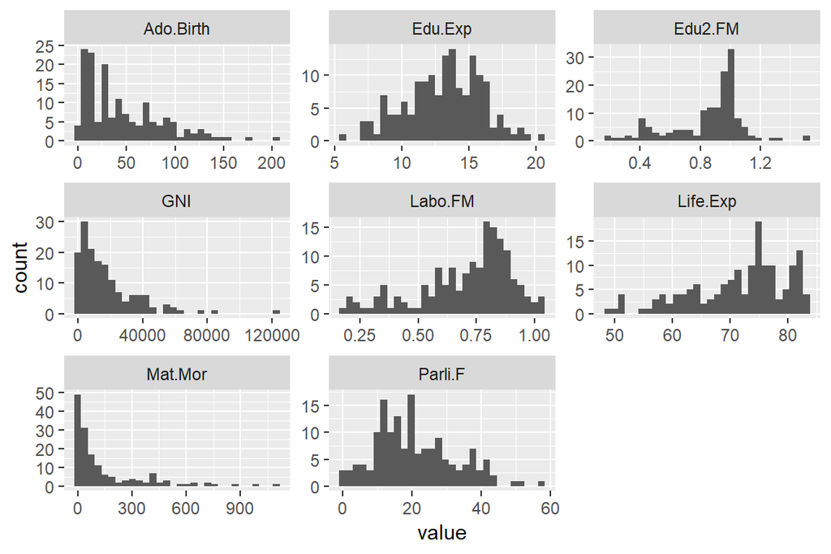

```r
library(corrplot); library(dplyr);library(tidyr); library(ggplot2); library(GGally)

# drawing a histogram of each variable
gather(human) %>% ggplot(aes(value)) + facet_wrap("key", scales = "free") + geom_histogram()
```

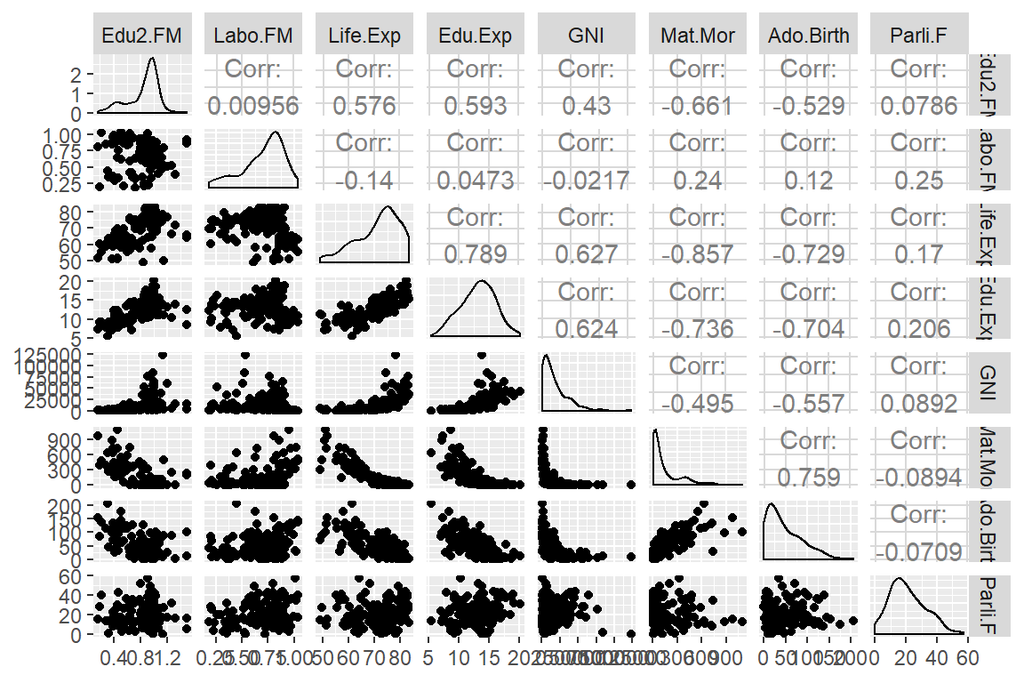

```r
# graphical overview using ggpairs
ggpairs(human)
```

Above is shown a graphical overview of the distributions of variables and correltions between them. Strongest negative correlation (-0.857) was found between maternal mortality ratio (*Mat.Mor*) and life expectancy at birth (*Life.Exp*). This means if maternal mortality ratio is higher, life expectancy at birth is lower, which sounds reasonable. Also gross national income per capita (*GNI*), expected years of schooling (*Edu.Exp*), and ratio of proportion of women with secondary eduaction to proportion of men with secondary education (*Edu2.FM*) correlated negatively with maternal mortality ratio, whereas adolescent birth rate (*Ado.Birth*) correlated positively with maternal mortality ratio. A strong positive correlation (0.789) was also found between life expectancy at birth and expected years of schooling. A visual presentation of the correlation matrix is shown below.

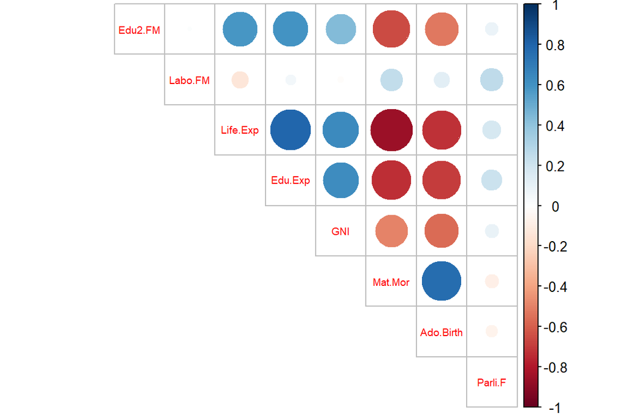

```r
# calculating and the correlation matrix
cor_matrix<-cor(human) %>% round(2)

# visualizing the correlation matrix
corrplot(cor_matrix, method="circle", type="upper", tl.pos = "d", tl.cex = 0.6)
```

## 2.-4. Principal component analysis (PCA)

### PCA on the non-standardized ‘human’ data

PCA was first done for the original, non-standardized data. The percentage of variability explained by the principal components is shown below. It looks like the first component explaines 100 % variance in the data, and there is none left for other components to explain.

```r
#PCA
pca_human <- prcomp(human)

# create and print out a summary of pca_human
s <- summary(pca_human)

# rounded percetanges of variance captured by each PC
pr_var_pca_human <- round(100*s$importance[2, ], digits =1)
pr_var_pca_human
```

```
## PC1 PC2 PC3 PC4 PC5 PC6 PC7 PC8
## 100   0   0   0   0   0   0   0
```

The biplot below shows that the first principal component is driven by GNI, which has a very high negative correlation with the component; The arrow for GNI is aligned with the x axis, but it goes to opposite direction.

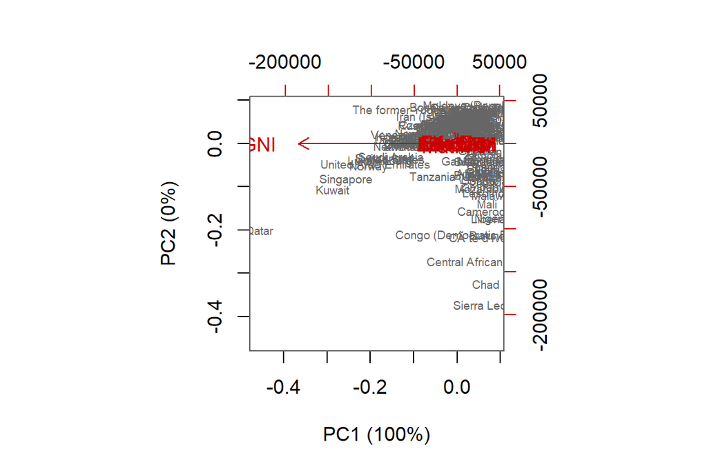

```r
# Labels for biplot
lab_pc_human <- paste0(names(pr_var_pca_human), " (", pr_var_pca_human, "%)")

# draw a biplot
biplot(pca_human, choices = 1:2, cex = c(0.6, 1), col = c("grey40", "red3"), xlab = lab_pc_human[1], ylab = lab_pc_human[2])
```

### PCA on standardized data

The data was standardized so that the mean of each variable was set to 0 and standard deviation to 1. After that, the PCA was applied to standardized data. The percentage of variability explained by the principal components is shown below. Now there is a lot more variability how much of the variance is explained by each of the components. The first principal component explaines 53.6% and the second principal component explaines 16.2% of the variance in the standardized data. The results are so different compared to results with non-standardized data, because in PCA, a variable with the highest variation has the highest importance. Because GNI varies on a scale from 0 to over 120000, it also has very much higher variation compared to other variables. Scaling the dataset gives all variables same standard deviation and therefore equal importance in PCA.

```r
#standardizing
human_std <- scale(human)

#PCA
pca_human_std <- prcomp(human_std)

# create and print out a summary of pca_human
s_std <- summary(pca_human_std)

# rounded percetanges of variance captured by each PC
pr_var_pca_human_std <- round(100*s_std$importance[2, ], digits =1)
pr_var_pca_human_std
```

```
##  PC1  PC2  PC3  PC4  PC5  PC6  PC7  PC8
## 53.6 16.2  9.6  7.6  5.5  3.6  2.6  1.3
```

A biplot on standardized data shows that *Parli.F* and *Labo.FM* load highly on the second principal component, and rest of the variables load highly on the first principal component.

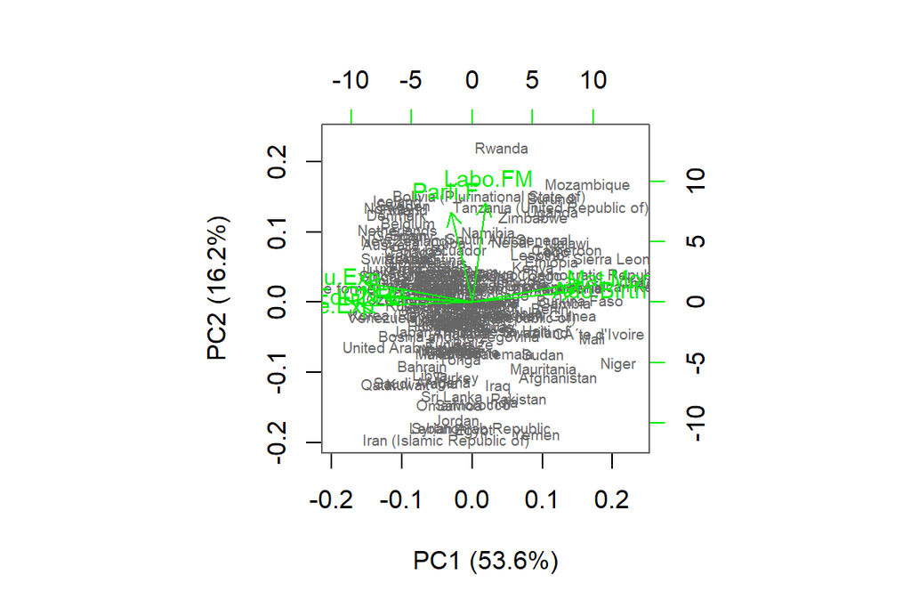

```r
# Labels for biplot
lab_pc_human_std <- paste0(names(pr_var_pca_human_std), " (", pr_var_pca_human_std, "%)")

# draw a biplot
biplot(pca_human_std, choices = 1:2, cex = c(0.6, 0.9), col = c("grey40", "green2"), xlab = lab_pc_human_std[1], ylab = lab_pc_human_std[2])
```

##### **A biplot on standardized data.** Variable names: Edu.Exp = “Expexted years of schooling”, Life.Exp = “Life expectancy at birth”, GNI = “Gross National Income per capita”, EDU2.FM = “women to men ratio completed secondary education”, Mat.Mor = “Maternal mortality ratio”, Ado.Birth=“Adolescent birth rate”, Labo.FM = “ratio of proportion of women in labour force to proportoion of men in labour force”, Parli.F = “PErcentage of female representatives in parliament”

### Interpretations of the first two principal component dimension based on the biplot on standardized data

The first principal component correlates positively with adolescent birth rate (*Ado.Birth*) and maternal mortality rate (*Mat.Mor*) and it correlates negatively with life expectancy at birth (*Life.Exp*), women to men education ratio (*Edu2.FM*), gross national income per capita (*GNI*), and expected years of schooling (*Edu.Exp*). This means that a country scoring high on first principal component has high maternal mortality ratio and adolescent birth rate, as well as low life expectancy at birth, low GNI and low expected years of schooling. Also a lower proportion of women compared to proportion of men in that country have completed secondary education.

The second principal component correlates positiviely with percentage of female representatives in parliament (*Parli.F*) and women to men labour force ratio (*Labo.FM*) This means that in a country scoring high on the second principal component, there is a high percentage of female representatives in parliament, and there is a high proportion of women compared to proportion of men in labour force.

## 5. Multiple Correspondence Analysis (MCA)

The ‘tea’ dataset from the FactoMineR package was loaded. The original dataset contained 36 variables and 300 observations. Below are shown the dimensions ans structure of the data, as well as data visualization as barplots.

```r
library(FactoMineR)

data("tea")

dim(tea)
```

```
## [1] 300  36
```

```r
str(tea)
```

```
## 'data.frame':    300 obs. of  36 variables:
##  $ breakfast       : Factor w/ 2 levels "breakfast","Not.breakfast": 1 1 2 2 1 2 1 2 1 1 ...
##  $ tea.time        : Factor w/ 2 levels "Not.tea time",..: 1 1 2 1 1 1 2 2 2 1 ...
##  $ evening         : Factor w/ 2 levels "evening","Not.evening": 2 2 1 2 1 2 2 1 2 1 ...
##  $ lunch           : Factor w/ 2 levels "lunch","Not.lunch": 2 2 2 2 2 2 2 2 2 2 ...
##  $ dinner          : Factor w/ 2 levels "dinner","Not.dinner": 2 2 1 1 2 1 2 2 2 2 ...
##  $ always          : Factor w/ 2 levels "always","Not.always": 2 2 2 2 1 2 2 2 2 2 ...
##  $ home            : Factor w/ 2 levels "home","Not.home": 1 1 1 1 1 1 1 1 1 1 ...
##  $ work            : Factor w/ 2 levels "Not.work","work": 1 1 2 1 1 1 1 1 1 1 ...
##  $ tearoom         : Factor w/ 2 levels "Not.tearoom",..: 1 1 1 1 1 1 1 1 1 2 ...
##  $ friends         : Factor w/ 2 levels "friends","Not.friends": 2 2 1 2 2 2 1 2 2 2 ...
##  $ resto           : Factor w/ 2 levels "Not.resto","resto": 1 1 2 1 1 1 1 1 1 1 ...
##  $ pub             : Factor w/ 2 levels "Not.pub","pub": 1 1 1 1 1 1 1 1 1 1 ...
##  $ Tea             : Factor w/ 3 levels "black","Earl Grey",..: 1 1 2 2 2 2 2 1 2 1 ...
##  $ How             : Factor w/ 4 levels "alone","lemon",..: 1 3 1 1 1 1 1 3 3 1 ...
```

[output cut: 22 more lines]

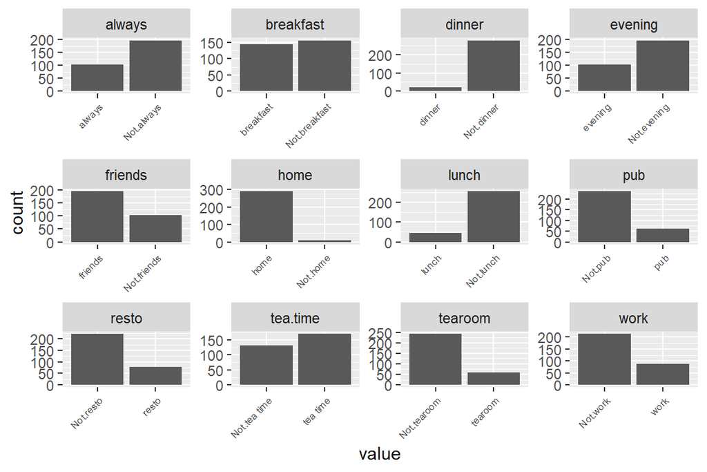

```r
gather(tea[1:12]) %>% ggplot(aes(value)) + facet_wrap("key", scales = "free") + geom_bar() + theme(axis.text.x = element_text(angle = 45, hjust = 1, size = 6))
```

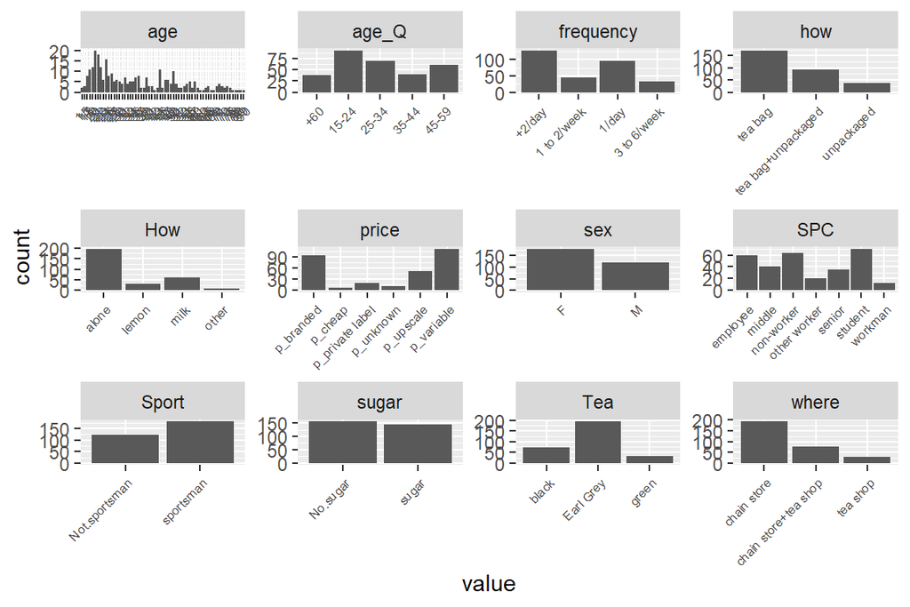

```r
gather(tea[13:24]) %>% ggplot(aes(value)) + facet_wrap("key", scales = "free") + geom_bar() + theme(axis.text.x = element_text(angle = 45, hjust = 1, size = 6))
```

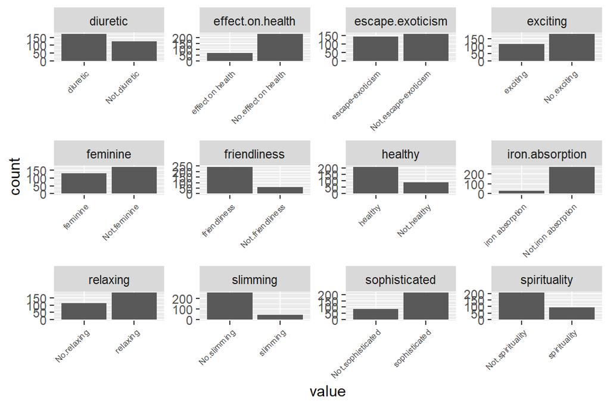

```r
gather(tea[25:36]) %>% ggplot(aes(value)) + facet_wrap("key", scales = "free") + geom_bar() + theme(axis.text.x = element_text(angle = 45, hjust = 1, size = 6))
```

I leave the variable *age* out of the MCA because it seem to be contionuous and there is also a categorical age variable (*age_Q*) in the data. Below is shown a biplot on ‘tea’ dataset without variable *age*. Because there is so many variables, the plot looks messy.

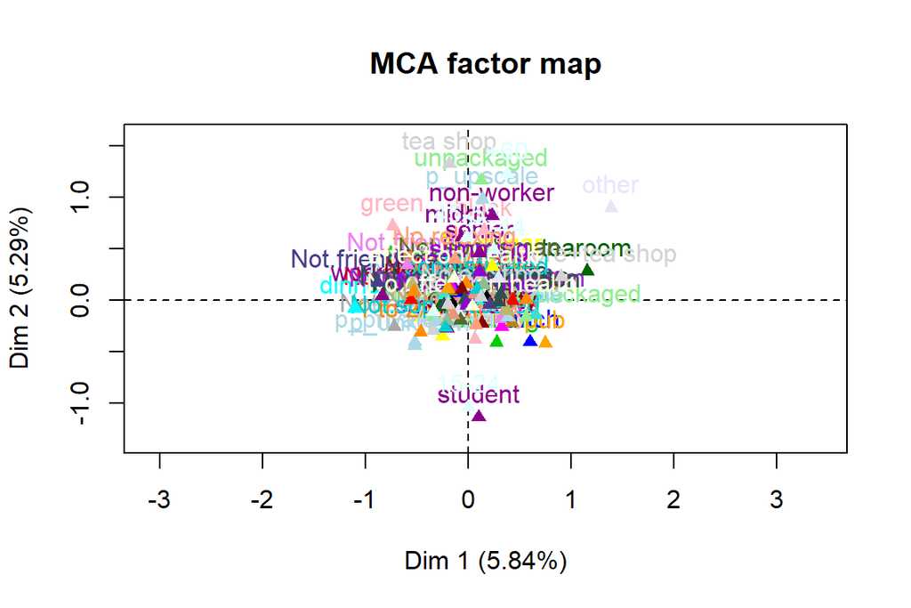

```r
tea2 <- dplyr::select(tea, -age)

# multiple correspondence analysis
mca <- MCA(tea2, graph = FALSE)

# visualize MCA
plot(mca, invisible=c("ind"), habillage="quali")
```

To keep the exercise and interpretation more simple, I choose six interesting variables from ‘tea’ dataset for MCA (*breakfast, sex, sugar, feminine, relaxing,* and *how*).

```r
tea3 <- dplyr::select(tea, c("breakfast","sex", "sugar", "feminine", "relaxing", "how"))

# multiple correspondence analysis
mca2 <- MCA(tea3, graph = FALSE)

# summary of the model
summary(mca2)
```

```
##
## Call:
## MCA(X = tea3, graph = FALSE)
##
##
## Eigenvalues
##                        Dim.1   Dim.2   Dim.3   Dim.4   Dim.5   Dim.6
## Variance               0.244   0.197   0.187   0.158   0.153   0.133
## % of var.             20.917  16.901  16.044  13.519  13.145  11.436
## Cumulative % of var.  20.917  37.818  53.862  67.381  80.526  91.962
##                        Dim.7
## Variance               0.094
## % of var.              8.038
## Cumulative % of var. 100.000
##
## Individuals (the 10 first)
##                  Dim.1    ctr   cos2    Dim.2    ctr   cos2    Dim.3
## 1             |  0.683  0.637  0.412 | -0.041  0.003  0.001 |  0.000
## 2             | -0.176  0.042  0.032 |  0.452  0.346  0.209 |  0.027
## 3             | -0.194  0.052  0.049 | -0.089  0.013  0.010 |  0.027
## 4             |  0.664  0.603  0.475 | -0.582  0.573  0.365 |  0.000
## 5             |  0.447  0.273  0.214 |  0.132  0.030  0.019 | -0.351
## 6             |  0.375  0.192  0.155 | -0.130  0.029  0.019 |  0.095
## 7             |  0.447  0.273  0.214 |  0.132  0.030  0.019 | -0.351
## 8             | -0.700  0.669  0.561 | -0.358  0.217  0.147 |  0.040
## 9             |  0.463  0.293  0.183 |  0.681  0.783  0.395 | -0.517
## 10            |  0.463  0.293  0.183 |  0.681  0.783  0.395 | -0.517
##                  ctr   cos2
## 1              0.000  0.000 |
## 2              0.001  0.001 |
## 3              0.001  0.001 |
## 4              0.000  0.000 |
## 5              0.219  0.132 |
## 6              0.016  0.010 |
## 7              0.219  0.132 |
## 8              0.003  0.002 |
## 9              0.477  0.229 |
## 10             0.477  0.229 |
##
## Categories (the 10 first)
```

[output cut: 16 more lines]

```
## No.sugar       10.406 |   0.120   0.663   0.015   2.147 |
## sugar         -10.406 |  -0.128   0.709   0.015  -2.147 |
## feminine       -6.134 |   0.020   0.015   0.000   0.295 |
## Not.feminine    6.134 |  -0.015   0.011   0.000  -0.295 |
## No.relaxing     6.219 |   0.722  17.486   0.315   9.706 |
## relaxing       -6.219 |  -0.436  10.566   0.315  -9.706 |
##
## Categorical variables (eta2)
##                 Dim.1 Dim.2 Dim.3
## breakfast     | 0.012 0.122 0.335 |
## sex           | 0.687 0.003 0.008 |
## sugar         | 0.184 0.362 0.015 |
## feminine      | 0.550 0.126 0.000 |
## relaxing      | 0.006 0.129 0.315 |
## how           | 0.026 0.440 0.450 |
```

The model summary above shows that the first dimension explains 20.9% and the second dimension explaines 16.9% of the variance in these six variables from ‘tea’ dataset. The two dimensional solution would not be very good at explaining the total variance, since the rest of the dimensions (3-6) also explain considerable amount of the variance in these variables (11.4-16.0%).

The first two dimensions are shown in the biplot below. It can bee seen that being male (*M*) and considering tea drinkin not feminine (*Not.feminine*) are guire close to eah other. The categories of *sex* and *feminine* are at the opposite ends of x-axis, meaning that these variables determine the first dimension. Also variable *sugar* contributes to the first dimension. The second dimension is more messy, but as already discribed it is mainly driven by *sugar* and *how*.

I guess that the third dimension can also kind of be seen from this biplot, because it shows that using tea bags, not drinking tea for breakfast and considering tea as relaxing “belong together”, since they are close to each other in a plot. At the same time, using unpacked tea, drinking tea for breakfast, and considering tea not relaxing belong also together.

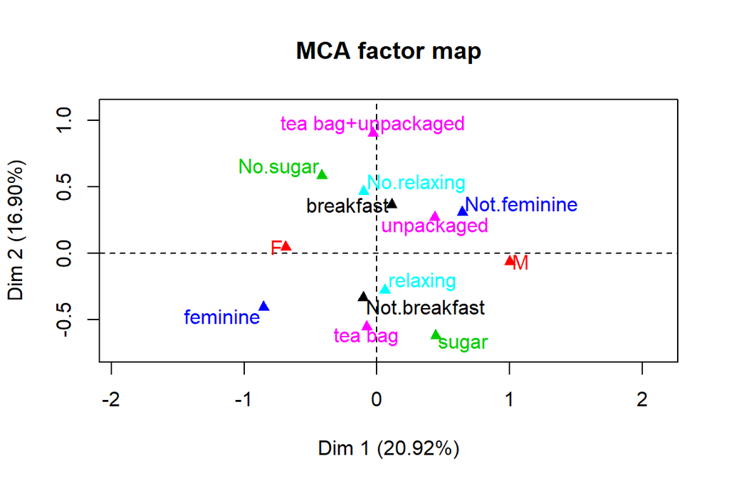

```r
# visualize MCA
plot(mca2, invisible=c("ind"), habillage="quali")
```

# Rstudio exercise 6

The task in the Rstudio exercise 6 is to repeat the analyses done in chapters 8 and 9 of MABS (Vehkalahti and Everitt, 2019), but use the two datasets in reverse order. In chapter 8 of MABS, the analyses are done with BPRS data, but in this exercise we implepent the analyses using RATS data. Similarly, we implement the analyses of chapter 9 of MABS using the BPRS data even though they were originally done with RATS data. To make my report easier to follow, I have used same numbers for figures and tables as were used in th chapters of MABS.

## The analyses of Chapter 8 of MABS using RATS data

```r
# accessing the data and re-converting ID and Group as factors

RATS <- read.table("https://raw.githubusercontent.com/KimmoVehkalahti/MABS/master/Examples/data/rats.txt", sep = '\t', header = T)

RATS$ID <- factor(RATS$ID)
RATS$Group <- factor(RATS$Group)

RATSL <- read.csv(file="~/GitHub/IODS-project/data/RATSL.csv")

RATSL$ID <- factor(RATSL$ID)
RATSL$Group <- factor(RATSL$Group)
```

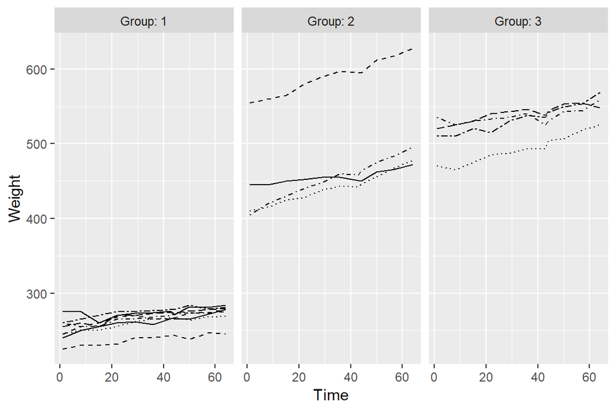

```r
library(ggplot2)

# Drawing the figure 8.1 using RATS data
ggplot(RATSL, aes(x = Time, y = Weight, linetype = ID)) +
  geom_line() +
  scale_linetype_manual(values = rep(1:10, times=4)) +
  facet_grid(. ~ Group, labeller = label_both) +
  theme(legend.position = "none") +
  scale_y_continuous(limits = c(min(RATSL$Weight), max(RATSL$Weight)))
```

##### **FIGURE 8.1** Individual growth by diet (Group) for the RATS data

In the Figure 8.1 all weights from all time points are plotted separately for each diet group. Each line represents one rat. It can easily be seen, that the baseline weight in Group 1 is a lot lower compared to groups 2 and 3. The rats in group 1 also don’s seem to grow much. The lines in each group seem very aligned, so there is not much invidiual variablitiy.

In next plot (Figure 8.2) the standardized values of each observation are plotted. The standardiced values were calculated by subtracting the relevant occasion mean from the original observation and then dividing by the corresponding visit standard deviation. From the scaled plot, the effect of the baseline value is more easily seen, and now we see some individual variablity more clearly. For example, the solid line in Group 2 has quite high weight at baseline and a bit slower groth compared to other rats in that group. In the plot using standardized values, the standardized weight recreases rather than increases.

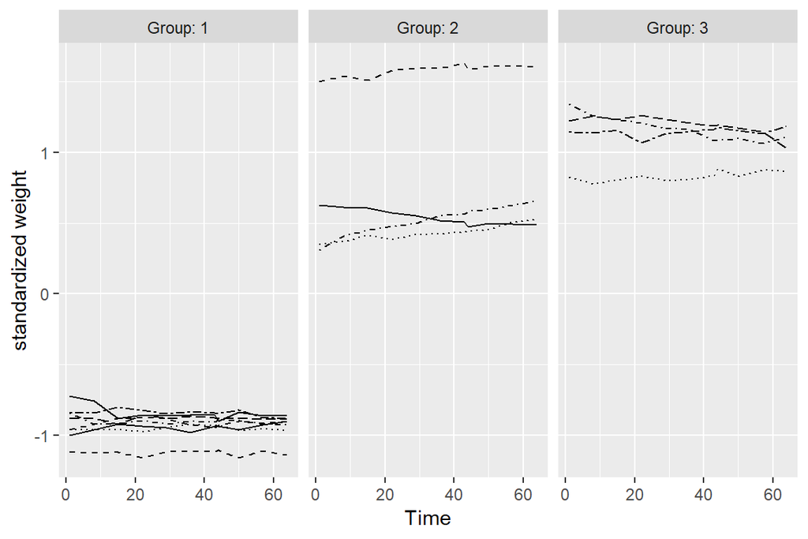

```r
library(dplyr)

# Standardising the weight
RATSL <- RATSL %>%
  group_by(Time) %>%
  mutate(stdWeight = (Weight - mean(Weight))/sd(Weight) ) %>%
  ungroup()

# Plotting again with the standardised weight
ggplot(RATSL, aes(x = Time, y = stdWeight, linetype = ID)) +
  geom_line() +
  scale_linetype_manual(values = rep(1:10, times=4)) +
  facet_grid(. ~ Group, labeller = label_both) +
  theme(legend.position = "none") +
  scale_y_continuous(name = "standardized weight")
```

##### **FIGURE 8.2** Individual growth by diet for RATS data after standardization.

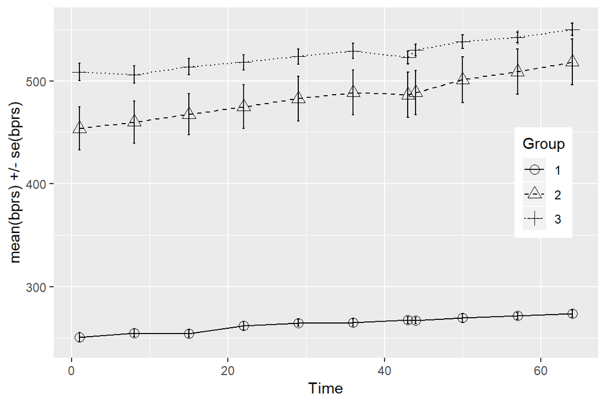

```r
library(tidyr)

# Number of timepoints, baseline included
n <- RATSL$Time %>% unique() %>% length()

# Summary data with mean and standard error of bprs by treatment and week
RATSL_summary <- RATSL %>%
  group_by(Group, Time) %>%
  summarise( mean = mean(Weight), se = sd(Weight)/sqrt(n) ) %>%
  ungroup()

# Plot the mean profiles
ggplot(RATSL_summary, aes(x = Time, y = mean, linetype = Group, shape = Group)) +
  geom_line() +
  scale_linetype_manual(values = c(1,2,3)) +
  geom_point(size=3) +
  scale_shape_manual(values = c(1,2,3)) +
  geom_errorbar(aes(ymin = mean - se, ymax = mean + se, linetype="1"), width=0.3) +
  theme(legend.position = c(0.9,0.5)) +
  scale_y_continuous(name = "mean(bprs) +/- se(bprs)")
```

##### **FIGURE 8.3** Mean growth for the diets in the RATS data.

In the Figure 8.3 the mean growth for the three diet groups is presented. Same can be seen here as earlier, the mean weight of rats in Group 1 is lower, as well as the mean growth rate seems to be lower. Other approach to plot summaries is to use boxplots (Figure 8.4).

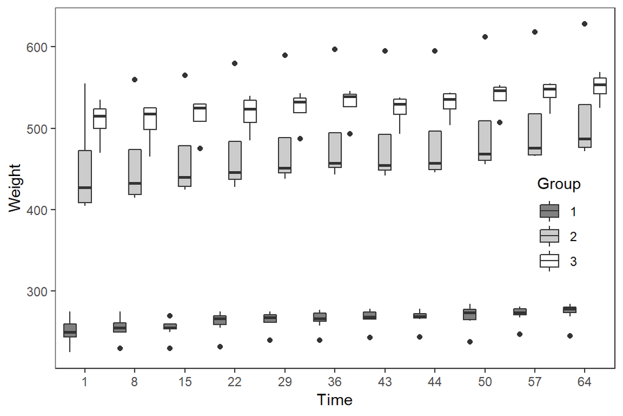

```r
#Drawing the figure 8.4 using RATS data

ggplot(RATSL, aes(x = factor(Time), y = Weight, fill = Group))+
  geom_boxplot(position = position_dodge(width = 0.9)) +
  theme_bw() + theme(panel.grid.major = element_blank(), panel.grid.minor = element_blank()) +
  theme(legend.position = c(0.9,0.4)) +
  scale_x_discrete(name = "Time") +
  scale_y_continuous(name = "Weight") +
  scale_fill_grey(start = 0.5, end = 1)
```

##### **FIGURE 8.4** Boxplots for summaries of weight for the diets at each time point in the RATS data.

Boxplots gives also a possiblity to identify outliers. In group 2 there is one rat with considerable higher weight than others which can bee seen from the figure 8.5 where mean weights of each rat at all timepoints after baseline are plotted. I’m quite hesitant to identify this rat as an otlier, because the weight is clearly at possible range and from the earlier figures we see that the growth of this heavy rat is similar compared to other is that group. However, for educational purposes, I filter out this rat and draw the figure 8.6 without it.

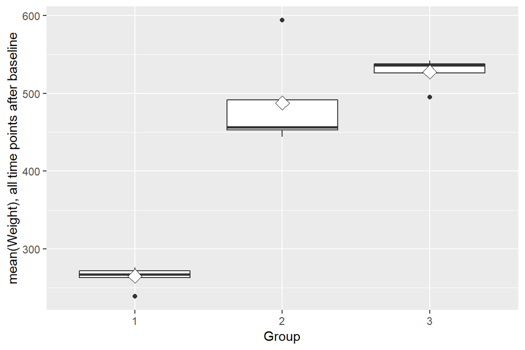

```r
#Drawing the figure 8.5 using RATS data

RATSL_summary2<- RATSL %>%
  filter(Time > 1) %>%
  group_by(Group, ID) %>%
  summarise(mean=mean(Weight) ) %>%
  ungroup()

ggplot(RATSL_summary2, aes(x = Group, y = mean)) +
  geom_boxplot() +
  stat_summary(fun.y = "mean", geom = "point", shape=23, size=4, fill = "white") +
  scale_y_continuous(name = "mean(Weight), all time points after baseline")
```

##### **FIGURE 8.5** Boxplots of mean weight for the diet groups in the RATS data.

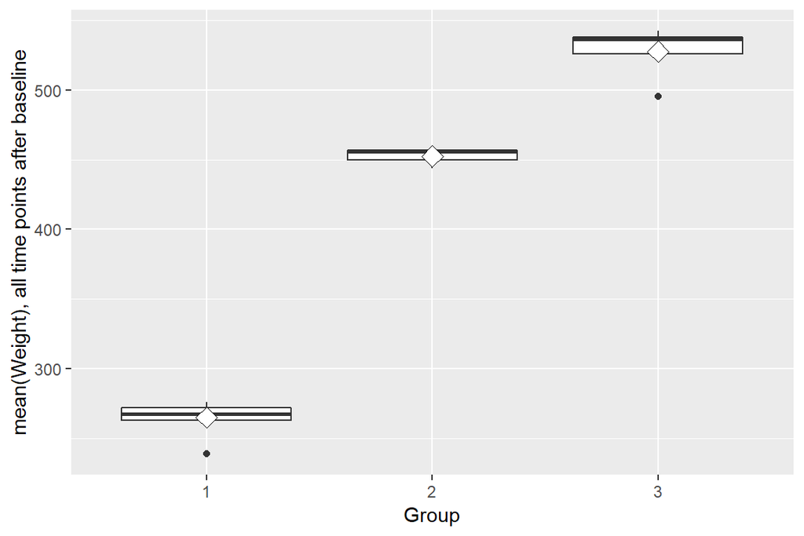

```r
# Filtering out the heavy rat in group 2 and drawing the figure 8.6
RATSL_summary2F <- RATSL_summary2 %>% filter (mean <560)

ggplot(RATSL_summary2F, aes(x = Group, y = mean)) +
  geom_boxplot() +
  stat_summary(fun.y = "mean", geom = "point", shape=23, size=4, fill = "white") +
  scale_y_continuous(name = "mean(Weight), all time points after baseline")
```

##### **FIGURE 8.6** Boxplots of mean weight for the diet groups in the RATS data without an outlier (a heavy rat in Group 2).

The differences between diet groups can’t be tested with t-test as was done in chapter 8 for BPRS data, because t-test can only deal with two groups. The analysis of covariance (Table 8.4) is possible. From the ANCOVA table (Table 8.4) we see that the mean weights in diet groups are not different when the baseline weight is taken into account (p=0.076).

##### **TABLE 8.4** Results from an analysis of covariance of the RATS Data with Baseline Weight and diet group covariates

```r
# Add the baseline weight from the original data as a new variable to the summary data:
RATSL_summary2b <- RATSL_summary2 %>%
  mutate(baseline = RATS$WD1)
# Fit the ANCOVA model and see the results:
fit <- lm(mean ~ baseline + Group, data = RATSL_summary2b)
anova(fit)
```

```
## Analysis of Variance Table
##
## Response: mean
##           Df Sum Sq Mean Sq   F value   Pr(>F)
## baseline   1 253625  253625 1859.8201 1.57e-14 ***
## Group      2    879     439    3.2219  0.07586 .
## Residuals 12   1636     136
## ---
## Signif. codes:  0 '***' 0.001 '**' 0.01 '*' 0.05 '.' 0.1 ' ' 1
```

## The analyses of Chapter 9 of MABS using BPRS data

First, we explore the data ignoring the repeated-measures structure (Figure 9.1 and Table 9.3).

```r
# accessing the data and re-converting treatment and subject as factors

BPRS <- read.table("https://raw.githubusercontent.com/KimmoVehkalahti/MABS/master/Examples/data/BPRS.txt", sep  =" ", header = T)

BPRS$treatment <- factor(BPRS$treatment)
BPRS$subject <- factor(BPRS$subject)

BPRSL <- read.csv(file="~/GitHub/IODS-project/data/BPRSL.csv")

BPRSL$treatment <- factor(BPRSL$treatment)
BPRSL$subject <- factor(BPRSL$subject)
```

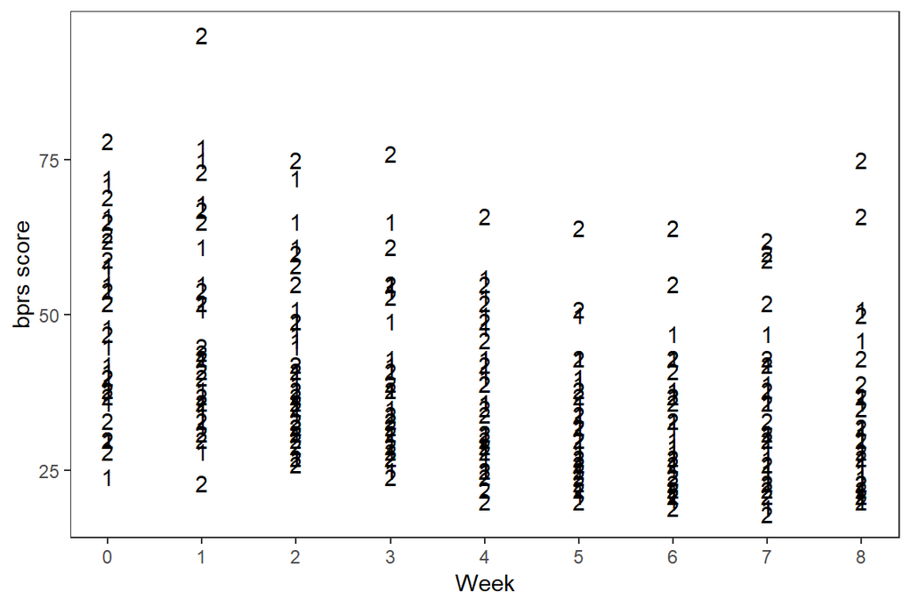

```r
# Drawing the Fig 9.1
ggplot(BPRSL, aes(x = week, y = bprs, group = subject)) +
  geom_text(aes(label = treatment)) +
  scale_x_continuous(name = "Week", breaks = seq(0, 8, 1)) +
  scale_y_continuous(name = "bprs score") + theme_bw() +
  theme(panel.grid.major = element_blank(), panel.grid.minor = element_blank())
```

##### **FIGURE 9.1** Bprs score plotted agains weeks ignoring the repeated measures structure. The treatment to which each observations belongs identified with number.

Results from linear regression ignoring the repeated-measures structure (Table 9.3) show that treatment is not significantly associated with bprs score (p=0.661), but the regression on week is higly significant (p<0.001).

##### **TABLE 9.3** Linear regression model to BPRS data in *long form* with BPRS scores as target variable and treatment and week as explanatory variables. Ignoring the repeated-measures structure of the data.

```r
BPRS_reg <- lm(bprs ~ treatment + week, data = BPRSL)
summary(BPRS_reg)
```

```
##
## Call:
## lm(formula = bprs ~ treatment + week, data = BPRSL)
##
## Residuals:
##     Min      1Q  Median      3Q     Max
## -22.454  -8.965  -3.196   7.002  50.244
##
## Coefficients:
##             Estimate Std. Error t value Pr(>|t|)
## (Intercept)  46.4539     1.3670  33.982   <2e-16 ***
## treatment2    0.5722     1.3034   0.439    0.661
## week         -2.2704     0.2524  -8.995   <2e-16 ***
## ---
## Signif. codes:  0 '***' 0.001 '**' 0.01 '*' 0.05 '.' 0.1 ' ' 1
##
## Residual standard error: 12.37 on 357 degrees of freedom
## Multiple R-squared:  0.1851, Adjusted R-squared:  0.1806
## F-statistic: 40.55 on 2 and 357 DF,  p-value: < 2.2e-16
```

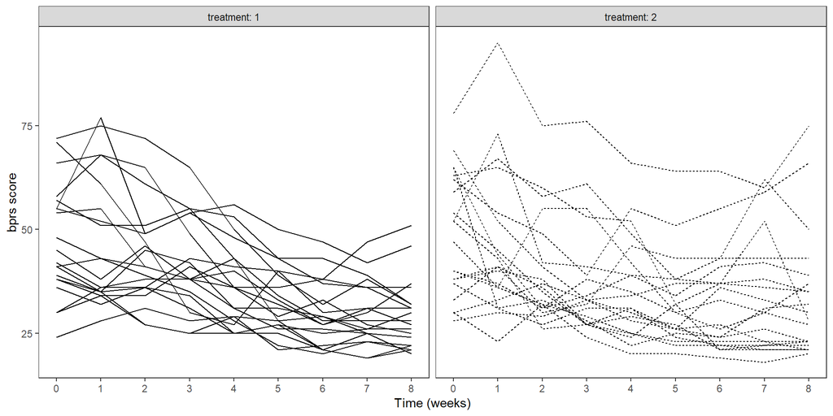

```r
# Drawing the Fig 9.2
ggplot(BPRSL, aes(x = week, y = bprs, group = subject)) +
  geom_line(aes(linetype = treatment)) +
  scale_x_continuous(name = "Time (weeks)", breaks = seq(0, 8, 1)) +
  scale_y_continuous(name = "bprs score") +
  theme_bw() + theme(legend.position = "none") +
  theme(panel.grid.major = element_blank(), panel.grid.minor = element_blank()) +
  facet_grid(. ~ treatment, labeller = label_both)
```